# Fact-checking

Joël Gombin

1 avril 2017

## Les familles dans le 15e arrondissement

### Part des familles

Source : https://www.insee.fr/fr/statistiques/2020310?sommaire=2106091&geo=COM-75115

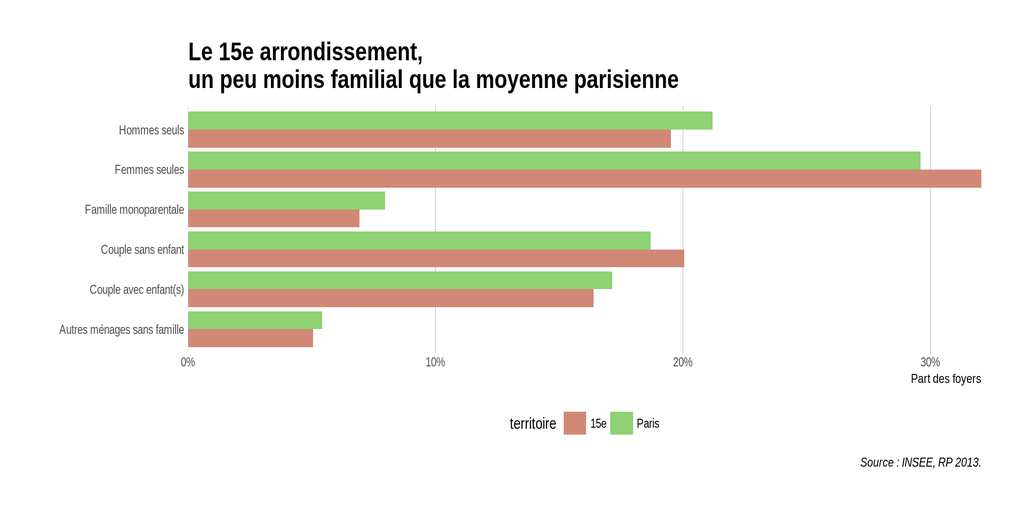

### Taille des familles

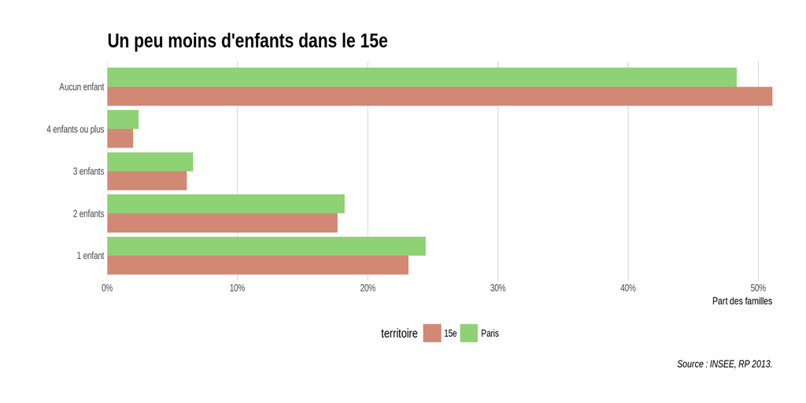

## Les modes de garde

Source : rapport APUR (http://www.apur.org/sites/default/files/documents/accueil_petite_enfance_paris.pdf)

D’après l’APUR, 75 % des enfants parisiens de moins de 3 ans, soit environ 56000 enfants, ont besoin d’être accueillis. 52 % des enfants de moins de 3 ans ont besoin d’être accueilli en mode collectif (crèche et autres), soit 38500 places. Elle peut monter jusqu’à 45500 places (61 %).

L’offre d’accueil collectif publique concerne environ 32000 places à Paris (soit le meilleur ratio par enfants de France). Il existe également environ 4700 places dans des structures privées non subventionnées (dont des enfants non parisiens peuvent également bénéficier).

Il faut noter que d’après l’APUR, 42 % des parents dont l’enfant est accueilli en garde à domicile, et 63 % de ceux dont l’enfant est accueilli par une assistante maternelle, auraient préféré bénéficier d’un autre mode d’accueil (contre 3 % pour la crèche collective).

Les capacités d’accueil sont par ailleurs inégalement réparties sur le territoire.

[figure not shown]

Le recours aux différents modes d’accueil est aussi très différencié selon les caractéristiques socioprofessionnelles des parents, et en particulier des mères.

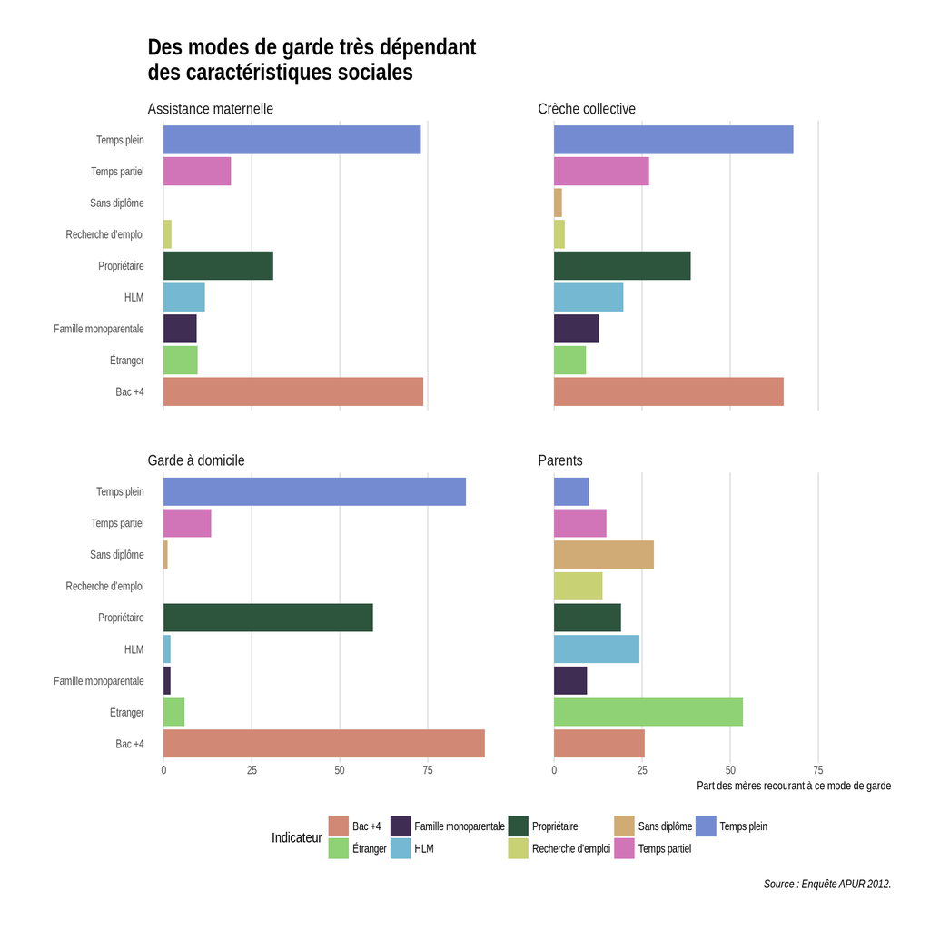

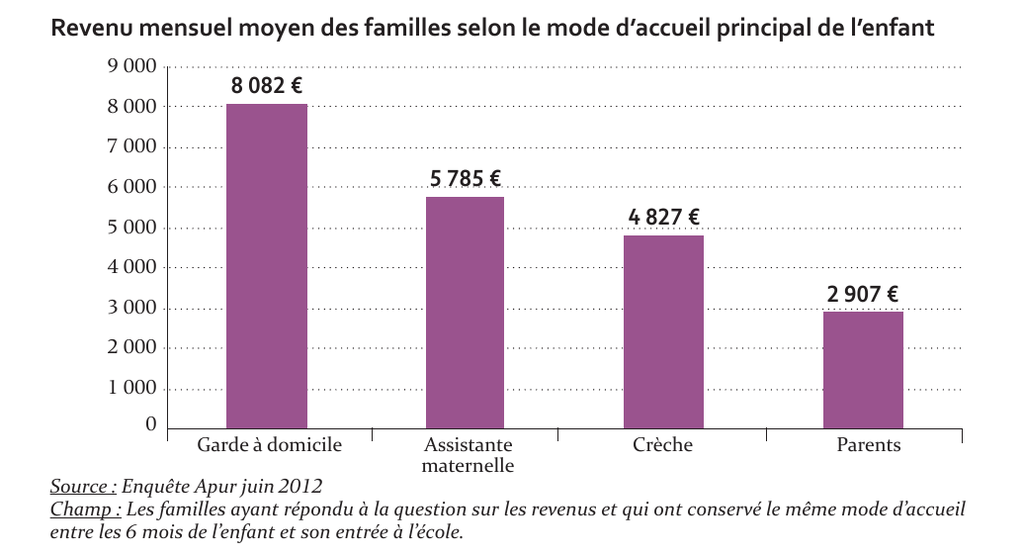